# walmart-recruiting-store-sales-forecasting_chingyuan

## Import Pcakages

```python
## basic
import itertools
import pandas as pd
import numpy as np
%matplotlib inline
import matplotlib.pyplot as plt
plt.style.use('fivethirtyeight')
import seaborn as sns
from scipy import stats

## data process
from sklearn import preprocessing
from sklearn.preprocessing import StandardScaler
from sklearn.preprocessing import OneHotEncoder
from sklearn.model_selection import train_test_split
#from sklearn.cross_validation import KFold

## models
#!pip install xgboost
import xgboost as xgb
from xgboost import DMatrix, XGBRegressor as XGB
from xgboost import plot_importance
from sklearn.metrics import mean_absolute_error


## utils
from validating import evaluate_forecast
from train_curve import plot_training_curve

#!pip install jupyter_contrib_nbextensions
#!jupyter contrib nbextension install --user
#!jupyter nbextension enable spellchecker/main
# !pip install jupyterthemes
# !jt -t chesterish
```

```python
print(pd.__version__)
print(np.__version__)
print(sns.__version__)
```

```
0.25.3
1.17.4
0.9.0
```

```python
## plot functions

def dist_plot(df, col, colors):

    fig, ax = plt.subplots(figsize=(12,4))
    ax = sns.distplot(
        df[col], kde=False, fit=stats.gamma, color=colors
    )
    plt.title(col)
    plt.show()

def plot_training_curve(clf):

    df_dict = {}

    for eval_set, eval_metric_dict in clf.evals_result_.items():
        for eval_metric, eval_loss in eval_metric_dict.items():
            df_dict[eval_set] = eval_loss

    df = pd.DataFrame(df_dict)
    return df.plot()

def xgb_importance(xgb_clf, importance_type='weight', **kwargs):

    fig, ax = plt.subplots(figsize=(9,4))

    plot_importance(
        xgb_clf, importance_type=importance_type, ax=ax, **kwargs
    )
```

## I. Read Files

```python
df_train = pd.read_csv('../data/train.csv')
df_test = pd.read_csv('../data/test.csv')
df_store = pd.read_csv('../data/stores.csv')
df_feature = pd.read_csv('../data/features.csv')
```

```python
df_train = df_train[['Store', 'Dept', 'Date', 'IsHoliday', 'Weekly_Sales']]
df_train['label'] = 'train_set'
df_train.shape
```

```
(421570, 6)
```

```python
df_train['Date'].min()
```

```
'2010-02-05'
```

```python
df_train['Date'].max()
```

```
'2012-10-26'
```

```python
df_test['Weekly_Sales'] = 0
df_test['Weekly_Sales'] = df_test['Weekly_Sales'].astype(float)
df_test['label'] = 'test_set'
df_test.shape
```

```
(115064, 6)
```

```python
df_test['Date'].min()
```

```
'2012-11-02'
```

```python
df_test['Date'].max()
```

```
'2013-07-26'
```

```python
df_feature.shape
```

```
(8190, 12)
```

```python
df_feature['Date'].max()
```

```
'2013-07-26'
```

```python
df_store.nunique()
```

```
Store    45
Type      3
Size     40
dtype: int64
```

### a. Merge Raw Data

- For exploring data and feature engineering easily, let's merge all raw features first.

```python
df_merge = pd.concat([df_train, df_test])
df_merge = df_merge.set_index('Store').join(df_store.set_index('Store')).reset_index()
df_merge['Id'] = df_merge['Store'].astype(str) + '_' + df_merge['Date'].astype(str)
df_feature['Id'] = df_feature['Store'].astype(str) + '_' + df_feature['Date'].astype(str)
```

```python
drop_cols = ['Store', 'Date', 'IsHoliday']
df_merge_all = df_merge.set_index('Id').join(df_feature.drop(drop_cols, axis=1).set_index('Id')).reset_index()
```

```python
df_merge_all.head(1)
```

|  | Id | Store | Dept | Date | IsHoliday | Weekly_Sales | label | Type | Size | Temperature | Fuel_Price | MarkDown1 | MarkDown2 | MarkDown3 | MarkDown4 | MarkDown5 | CPI | Unemployment |
| --- | --- | --- | --- | --- | --- | --- | --- | --- | --- | --- | --- | --- | --- | --- | --- | --- | --- | --- |
| 0 | 10_2010-02-05 | 10 | 1 | 2010-02-05 | False | 40212.84 | train_set | B | 126512 | 54.34 | 2.962 | NaN | NaN | NaN | NaN | NaN | 126.442065 | 9.765 |

## II. Explore Data in Variables

### a. Check Missing Values

- `From Markdown_1 to Markdown_5` are related to whether have campagin promotions on the week.
- `CPI` and `Unemployment` displays some missing values.

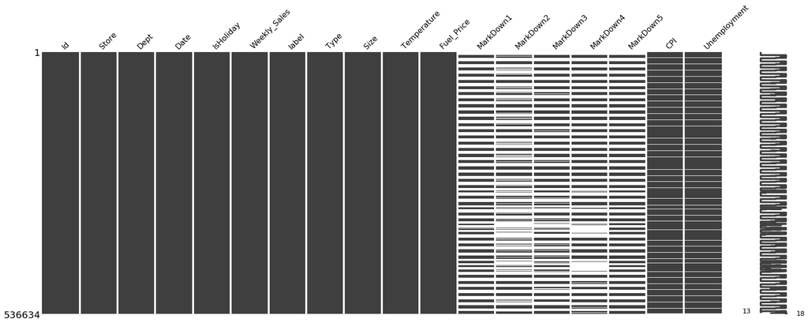

```python
import missingno as msno

msno.matrix(df_merge_all)
```

### b. Check Values in Variables

- `Weekly_Sales` indicates some negative values, will need to deal with it.
- `MarkDown` shows negative values values as well.

```python
df_merge_all.describe()
```

|  | Store | Dept | Weekly_Sales | Size | Temperature | Fuel_Price | MarkDown1 | MarkDown2 | MarkDown3 | MarkDown4 | MarkDown5 | CPI | Unemployment |
| --- | --- | --- | --- | --- | --- | --- | --- | --- | --- | --- | --- | --- | --- |
| count | 536634.000000 | 536634.000000 | 536634.000000 | 536634.00000 | 536634.000000 | 536634.000000 | 265596.000000 | 197685.000000 | 242326.000000 | 237143.000000 | 266496.000000 | 498472.000000 | 498472.000000 |
| mean | 22.208621 | 44.277301 | 12554.588392 | 136678.55096 | 58.771762 | 3.408310 | 7438.004144 | 3509.274827 | 1857.913525 | 3371.556866 | 4324.021158 | 172.090481 | 7.791888 |
| std | 12.790580 | 30.527358 | 21171.249456 | 61007.71180 | 18.678716 | 0.430861 | 9411.341379 | 8992.047197 | 11616.143274 | 6872.281734 | 13549.262124 | 39.542149 | 1.865076 |
| min | 1.000000 | 1.000000 | -4988.940000 | 34875.00000 | -7.290000 | 2.472000 | -2781.450000 | -265.760000 | -179.260000 | 0.220000 | -185.170000 | 126.064000 | 3.684000 |
| 25% | 11.000000 | 18.000000 | 49.852500 | 93638.00000 | 45.250000 | 3.041000 | 2114.640000 | 72.500000 | 7.220000 | 336.240000 | 1570.112500 | 132.521867 | 6.623000 |
| 50% | 22.000000 | 37.000000 | 4118.755000 | 140167.00000 | 60.060000 | 3.523000 | 5126.540000 | 385.310000 | 40.760000 | 1239.040000 | 2870.910000 | 182.442420 | 7.795000 |
| 75% | 33.000000 | 74.000000 | 15497.417500 | 202505.00000 | 73.230000 | 3.744000 | 9303.850000 | 2392.390000 | 174.260000 | 3397.080000 | 5012.220000 | 213.748126 | 8.549000 |
| max | 45.000000 | 99.000000 | 693099.360000 | 219622.00000 | 101.950000 | 4.468000 | 103184.980000 | 104519.540000 | 149483.310000 | 67474.850000 | 771448.100000 | 228.976456 | 14.313000 |

### c. Check Correlations in Variables

- `IsHoliday` shows a positve correlationn with `Markdown_2 and Markdown_3`.
- `Markdown_1` and `Markdown_4` indicates a strong positive correlationn.
- `Weekly_Sales` displays a slight positve correlation with `Size`, not clear with other variables.

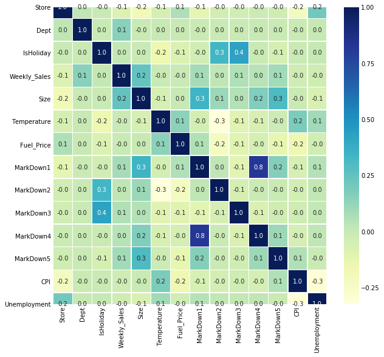

```python
f,ax = plt.subplots(figsize=(9,9))

sns.heatmap(
    df_merge_all[df_merge_all.label == 'train_set'].corr(),
    annot=True, linewidths=.5, fmt= '.1f', cmap='YlGnBu', ax=ax
)
```

### d. Weekly_Sales

- weekly sales in a desnity plot show mostly concentrate on `from 0 to 20000`.
- weekly sales with holiday effect indicate higher sales compared with weekly sales without holidy effect.
- weekly sales on `median` shows a seasonal pattern, especially during X'mas holidays and a distinct dent after X'mas holidays.

#### d1. Density for Weekly Sales

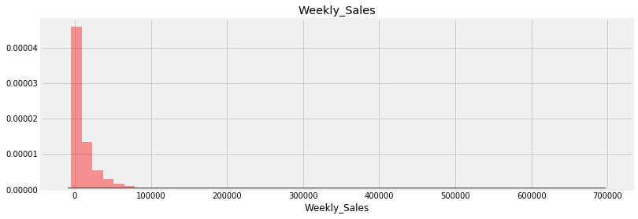

```python
dist_plot(df_merge_all, 'Weekly_Sales', 'r')
```

#### d2. Weekly Sales with Holidy Effects by Store

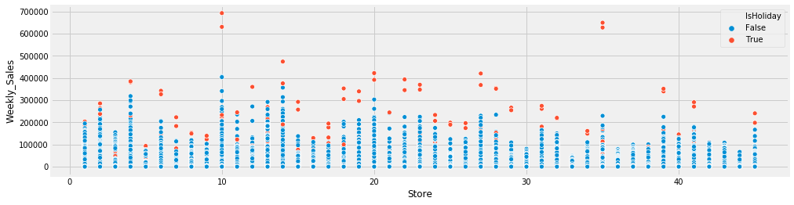

```python
fig, ax = plt.subplots(figsize=(15,4))

ax = sns.scatterplot(
    x='Store', y='Weekly_Sales', hue='IsHoliday', data=df_merge_all.iloc[0:]
)

plt.title('')
plt.show()
```

#### d3. Weekly Sales on Median

```python
group_by_date = df_merge_all.groupby(['Date','label'])['Weekly_Sales'].median().reset_index()
group_by_date['Date'] = pd.to_datetime(group_by_date['Date'])
group_by_date = group_by_date[group_by_date.label == 'train_set'].set_index('Date')
group_by_date = group_by_date.drop('label', axis=1)
```

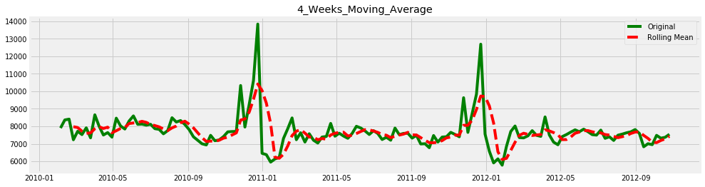

```python
win_weeks = 4

rolmean = group_by_date.rolling(window=win_days).mean()

fig, ax = plt.subplots(figsize=(15,4))

orig = plt.plot(group_by_date, color='g',label='Original')
mean = plt.plot(rolmean, color='r', label='Rolling Mean', linestyle='dashed')

plt.legend(loc='best')
plt.title(str(win_weeks) + '_Weeks_Moving_Average')
plt.show(block=False)
```

### e. Size

- Type_A is large size store, Type_B is medium size store and Type_C is small store.
- Type_A indicates higher weekly sales on median compared with Type_B and Type_C.

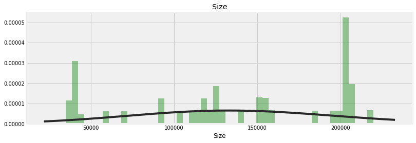

```python
dist_plot(df_merge_all, 'Size', 'g')
```

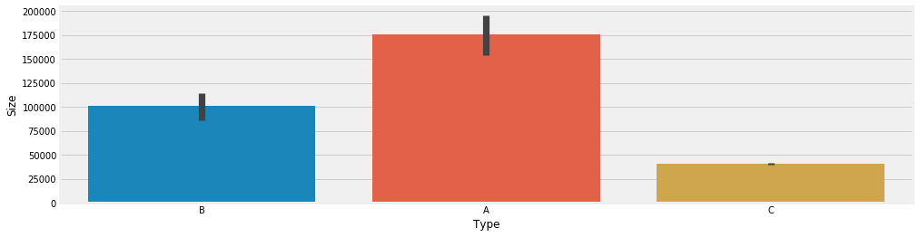

```python
group_size = df_merge_all.groupby(['Size','Type'])['Weekly_Sales'].mean().reset_index()

fig, ax = plt.subplots(figsize=(15,4))
ax = sns.barplot(x='Type', y='Size', data=group_size)
plt.title('')
plt.show()
```

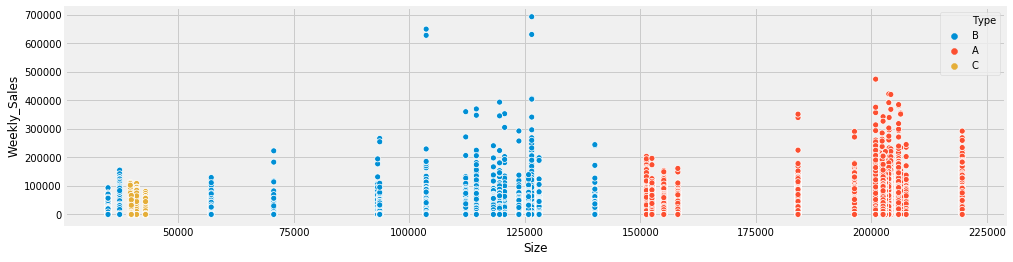

```python
fig, ax = plt.subplots(figsize=(15,4))

ax = sns.scatterplot(
    x='Size', y='Weekly_Sales', hue='Type', data=df_merge_all
)

plt.title('')
plt.show()
```

```python
df_merge_all.groupby(['Type'])['Weekly_Sales'].median().reset_index()
```

|  | Type | Weekly_Sales |
| --- | --- | --- |
| 0 | A | 5813.820 |
| 1 | B | 3496.860 |
| 2 | C | 414.345 |

### f. CPI and Unemployment

- `CPI` shows a variety of distribution in the data.
- `Unemployment` concentrates on 6 ~ 9.

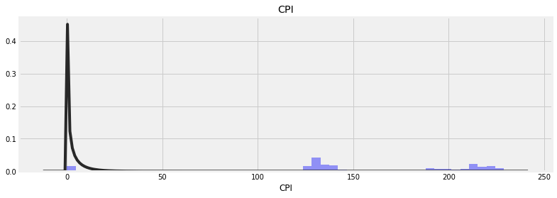

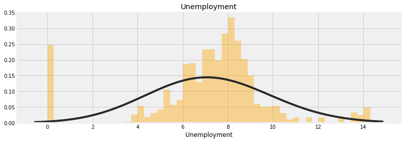

```python
dist_plot(df_merge_all.fillna(0), 'CPI', 'b')
dist_plot(df_merge_all.fillna(0), 'Unemployment', 'orange')
```

## III. Pre-Porcess and Feature Engineering

### a. Create Unique Id

- For training and pedicting data with an index in creating unique Ids.
- Id = store + dept + date

```python
df_merge_all['Id'] = df_merge_all['Store'].astype(str) + '_'  + df_merge_all['Dept'].astype(str) + '_'+ df_merge_all['Date'].astype(str)
```

### b. Deal with Negative Values in Logarithm`Weekly_Sales`

```python
df_merge_all['Weekly_Sales'] = df_merge_all['Weekly_Sales'].apply(lambda x: 0 if x < 0 else x)
```

### c. Transform `Type` to Dummies

```python
df_dummies = df_merge_all['Type'].astype('str')
df_dummies = pd.get_dummies(df_dummies, prefix_sep='_', drop_first=False)
```

### d. Transform `IsHoliday` to Boolean

```python
from mult_encoder import MultiColumnLabelEncoder

df_bool = MultiColumnLabelEncoder(columns=['IsHoliday']).fit_transform(df_merge_all[['IsHoliday']])
```

### e. Create Date Related Features

```python
df_date = df_merge_all[['Date']]
df_date['year'] = pd.to_datetime(df_date['Date']).dt.year
df_date['month'] = pd.to_datetime(df_date['Date']).dt.month
df_date['week_of_year'] = pd.to_datetime(df_date['Date']).dt.week
df_date = df_date.drop('Date', axis=1)
normalised_date = (df_date - df_date.min()) / (df_date.max() - df_date.min())
```

### f. Deal with `Markdown_1 to _5` by Normalised

For `Mrkdown_1 to Mrkdown_5`, lots of missed values are related to markdown promotions. We assumptions two stituations:

- There is no markdown promotions available for this Ids(Store + Dept + Date).
- There is markdown promotions in that week but no data.

```python
df_merge_all['MarkDown1'] = df_merge_all['MarkDown1'].apply(lambda x: 0 if x < 0 else x)
df_merge_all['MarkDown2'] = df_merge_all['MarkDown2'].apply(lambda x: 0 if x < 0 else x)
df_merge_all['MarkDown3'] = df_merge_all['MarkDown3'].apply(lambda x: 0 if x < 0 else x)
df_merge_all['MarkDown4'] = df_merge_all['MarkDown4'].apply(lambda x: 0 if x < 0 else x)
df_merge_all['MarkDown5'] = df_merge_all['MarkDown5'].apply(lambda x: 0 if x < 0 else x)
normalised_cols = df_merge_all[[
    'MarkDown1','MarkDown2','MarkDown3','MarkDown4','MarkDown5',
    'Size','Temperature','Fuel_Price','CPI','Unemployment',

]].fillna(0)
normalised_df = (normalised_cols - normalised_cols.min()) / (normalised_cols.max() - normalised_cols.min())
```

```python
df_merge_all['Unemployment'] = df_merge_all['Unemployment'].fillna(df_merge_all['Unemployment'].median())
df_merge_all['CPI'] = df_merge_all['CPI'].fillna(df_merge_all['CPI'].median())

## Another approch to deal with Unemployment and CPI
#from fancyimpute import KNN
#df_for_model['Unemployment'] = KNN(k=3).fit_transform(df_for_model['Unemployment'])
#df_for_model['CPI'] = KNN(k=3).fit_transform(df_for_model['CPI'])
```

### f. Add Lag Weekly Sales Feature

- For capturing weekly sales pattern in training, create a new lag sales feature in the training set.

```python
df_sales_lag = df_merge_all[['Weekly_Sales']].shift().rename(columns={'Weekly_Sales':'lag_sales'})
normalised_lag = (df_sales_lag - df_sales_lag.min()) / (df_sales_lag.max() - df_sales_lag.min())
```

### g. Merge All Processed Data

```python
df_final_for_model = df_merge_all[[
    'Id','label','Store','Dept'
]].join(df_dummies).join(df_bool).join(normalised_df).join(normalised_date).join(normalised_lag)
```

```python
X = df_final_for_model[df_final_for_model.label == 'train_set'].drop('label', axis=1).set_index('Id')
y = df_merge_all[df_merge_all.label == 'train_set'][['Weekly_Sales']]
X_test = df_final_for_model[df_final_for_model.label == 'test_set'].drop('label', axis=1).set_index('Id')
y_test = df_merge_all[df_merge_all.label == 'test_set'][['Weekly_Sales']]
```

```python
X.head(2)
```

| Id | Store | Dept | A | B | C | IsHoliday | MarkDown1 | MarkDown2 | MarkDown3 | MarkDown4 | MarkDown5 | Size | Temperature | Fuel_Price | CPI | Unemployment | year | month | week_of_year | lag_sales |
| --- | --- | --- | --- | --- | --- | --- | --- | --- | --- | --- | --- | --- | --- | --- | --- | --- | --- | --- | --- | --- |
| 10_1_2010-02-05 | 10 | 1 | 0 | 1 | 0 | 0 | 0.0 | 0.0 | 0.0 | 0.0 | 0.0 | 0.496013 | 0.564171 | 0.245491 | 0.552206 | 0.682247 | 0.0 | 0.090909 | 0.078431 | NaN |
| 10_2_2010-02-05 | 10 | 2 | 0 | 1 | 0 | 0 | 0.0 | 0.0 | 0.0 | 0.0 | 0.0 | 0.496013 | 0.564171 | 0.245491 | 0.552206 | 0.682247 | 0.0 | 0.090909 | 0.078431 | 0.058019 |

## IV. Training and Validating Models

In this case, we choose tree based algorithms for predicting `Weekly_Sales` as it is flexible to tune with `hyperopt` package and easy to interpret feature importances.

- Auto Tuned XGBoosting with hyperopt method.
- https://github.com/hyperopt/hyperopt

### a. Tuned XGB with Best Parameters

```python
from hyperopt import hp, tpe, STATUS_OK, Trials
from hyperopt.fmin import fmin

def objective(space):

    clf = xgb.XGBRegressor(
        n_estimators = space['n_estimators'],
        max_depth = space['max_depth'],
        min_child_weight = space['min_child_weight'],
        subsample = space['subsample'],
        learning_rate = space['learning_rate'],
        gamma = space['gamma'],
        colsample_bytree = space['colsample_bytree'],
        objective='reg:linear'
    )

    eval_set = [(X_train, y_train), (X_val, y_val)]

    clf.fit(X_train,
            y_train,
            eval_set=eval_set,
            eval_metric = 'mae')

    pred = clf.predict(X_val)
    #mae = mean_absolute_error(np.exp(y_valid), np.exp(pred))
    mae = mean_absolute_error((y_val), (pred))

    return{'loss':mae, 'status': STATUS_OK }
```

```python
X_train, X_val, y_train, y_val = train_test_split(X, y, test_size=0.2)

space ={
        'max_depth': hp.choice('max_depth', np.arange(10, 30, dtype=int)),
        'min_child_weight': hp.quniform ('min_child', 1, 20, 1),
        'subsample': hp.uniform ('subsample', 0.8, 1),
        'n_estimators' : hp.choice('n_estimators', np.arange(10, 100, 10, dtype=int)),
        'learning_rate' : hp.quniform('learning_rate', 0.025, 0.5, 0.025),
        'gamma' : hp.quniform('gamma', 0.5, 1, 0.05),
        'colsample_bytree' : hp.quniform('colsample_bytree', 0.5, 1, 0.05),
        'reg_alpha':hp.uniform ('reg_alpha', 0.001, 0.05),
        'colsample_bylevel': hp.quniform('colsample_bylevel', 0.5, 1, 0.05)
    }

trials = Trials()
best = fmin(fn=objective,
            space=space,
            algo=tpe.suggest,
            max_evals=3, # change
            trials=trials)

print(best)
```

[output not shown]

[output cut: 69 more lines]

```














{'colsample_bylevel': 0.55, 'colsample_bytree': 0.9, 'gamma': 0.8, 'learning_rate': 0.225, 'max_depth': 10, 'min_child': 11.0, 'n_estimators': 4, 'reg_alpha': 0.022711166127242128, 'subsample': 0.8645027328673522}
```

#### a1. Best Parameters for The Model

```python
best
```

```
{'colsample_bylevel': 0.55,
 'colsample_bytree': 0.9,
 'gamma': 0.8,
 'learning_rate': 0.225,
 'max_depth': 10,
 'min_child': 11.0,
 'n_estimators': 4,
 'reg_alpha': 0.022711166127242128,
 'subsample': 0.8645027328673522}
```

```python
def xgb_regressor(X, y):
    """
    learn_rate: 0.5-1
    eta: 0.01-0.2
    max_depth: 3-7, Used to control over-fitting as higher depth will allow model to learn relations
    very specific to a particular sample.
    subsample: 0.5-1, Lower values make the algorithm more conservative and prevents overfitting but
    too small values might lead to under-fitting.
    """

    X_train, X_val, y_train, y_val = train_test_split(X, y, test_size=0.2)

    xgb_clf = XGB(
        booster='gbtree',
        colsample_bytree=0.5,
        gamma=0.75,
        learning_rate=0.125,
        max_depth=10,
        min_child=8.0,
        n_estimators=400,
        subsample=0.9
    )

    xgb_clf.fit(
        X_train, y_train, eval_set=[(X_train, y_train), (X_val, y_val)], eval_metric='mae'
    )

    return xgb_clf

xgb_clf = xgb_regressor(X, y)
```

```
[01:01:33] WARNING: C:/Jenkins/workspace/xgboost-win64_release_0.90/src/objective/regression_obj.cu:152: reg:linear is now deprecated in favor of reg:squarederror.
```

#### b1. Predictions for Val_Set

```python
X_train, X_val, y_train, y_val = train_test_split(X, y, test_size=0.2)
y_pred = xgb_clf.predict(X_val)
```

#### b2. Validating

```python
mse = ((y_pred - np.array(y_val)[0]) ** 2).mean()
print('The Mean Squared Error of our forecasts is {}'.format(round(mse, 2)))
print('The Root Mean Squared Error of our forecasts is {}'.format(round(np.sqrt(mse), 2)))
```

```
The Mean Squared Error of our forecasts is 752739491.08
The Root Mean Squared Error of our forecasts is 27436.1
```

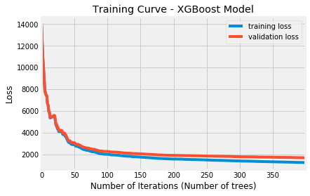

```python
ax = plot_training_curve(xgb_clf)
ax.set_title('Training Curve - XGBoost Model')
ax.set_xlabel('Number of Iterations (Number of trees)')
ax.set_ylabel('Loss')
ax.legend(['training loss', 'validation loss'])
```

#### b3. Importance Type

- `gain`: the average gain across all splits the feature is used in.
- `weight`: the number of times a feature is used to split the data across all trees.
- `cover`: the average coverage across all splits the feature is used in.

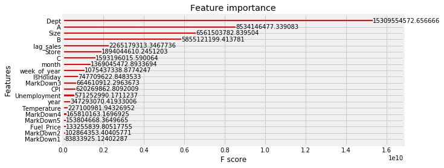

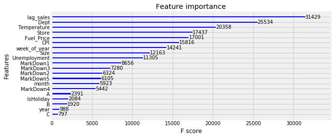

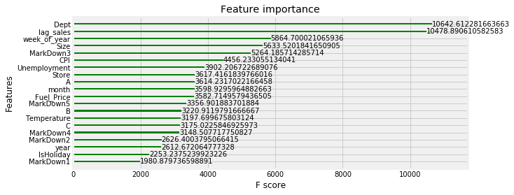

```python
xgb_importance(xgb_clf, importance_type='gain', color= 'r')
xgb_importance(xgb_clf, importance_type='weight', color= 'b')
xgb_importance(xgb_clf, importance_type='cover', color='g')
```

```python
y_pred = xgb_clf.predict(X_test)
output = X_test.reset_index()[['Id']]
output['Weekly_Sales'] = y_pred
```

```python
output.to_csv('submission.csv', index=False)
```

## VIII. Improvement and Suggestion

#### On Data Level

- Create some new features to reflect sales distribution such as split sales to different segments and label it, fitting into the training model.
- Cross Validation with K-fold data.

#### On Model Level

- Try other algorithms such as NN or Time Series Forecasting.
- `Stacking mthods` with the combination of models can improve it.

```python
#     xgb_clf = XGB(
#         booster='gbtree',
#         colsample_bytree=0.5,
#         gamma=0.75,
#         learning_rate=0.125,
#         max_depth=10,
#         min_child=8.0,
#         n_estimators=300,
#         subsample=0.9
#     )
```

```python
#     xgb_clf = XGB(
#         booster='gbtree',
#         colsample_bytree=0.9,
#         colsample_bylevel=0.55,
#         gamma=0.8,
#         learning_rate=0.225,
#         max_depth=10,
#         min_child=11.0,
#         n_estimators=300,
#         subsample=0.8645,
#         reg_alpha=0.227
#     )
```